# STAT 184: Final Project

Radha Patel and Srija Pinnamaneni

April 28, 2020

### Topic Overview

As the spread of COVID-19 continues to disrupt normal, American life, we are interested in looking at the number of cases in each state. We would like to look at the number of cases in each state and see if there is any sort of relationship with its general population. Our research looks at the number of cases in the United States starting on 1/22/20 and ending on 4/3/20. Essentially, our main research question is: What sort of relationship does state population and number of coronavirus case in each state have (positive, negative, or no correlation.)?

### Loading in necessary packages

```r
rm(list = ls())
library(readr)
library(tidyr)
library(dplyr)
library(rvest)
library(DataComputing) #Secondary dataset ZipGeography is in this package
library(lubridate)
library(leaflet)
```

### Loading in primary dataset

```r
covid_confirmed_usafacts <- read_csv("covid_confirmed_usafacts (1).csv")
```

Our primary data set is a data table containing cases that represent the number of coronavirus states per county in the United States. This was found on the website: https://usafacts.org/visualizations/coronavirus-covid-19-spread-map/ Our second data set is the ZipGeography data table found in the DataComputing package for use in R.

### Preliminary Analysis of Data

```r
nrow(covid_confirmed_usafacts)
```

```
[1] 3195
```

```r
names(covid_confirmed_usafacts)
```

```
 [1] "countyFIPS"  "County Name" "State"       "stateFIPS"   "1/22/20"
 [6] "1/23/20"     "1/24/20"     "1/25/20"     "1/26/20"     "1/27/20"
[11] "1/28/20"     "1/29/20"     "1/30/20"     "1/31/20"     "2/1/20"
[16] "2/2/20"      "2/3/20"      "2/4/20"      "2/5/20"      "2/6/20"
[21] "2/7/20"      "2/8/20"      "2/9/20"      "2/10/20"     "2/11/20"
[26] "2/12/20"     "2/13/20"     "2/14/20"     "2/15/20"     "2/16/20"
[31] "2/17/20"     "2/18/20"     "2/19/20"     "2/20/20"     "2/21/20"
[36] "2/22/20"     "2/23/20"     "2/24/20"     "2/25/20"     "2/26/20"
[41] "2/27/20"     "2/28/20"     "2/29/20"     "3/1/20"      "3/2/20"
[46] "3/3/20"      "3/4/20"      "3/5/20"      "3/6/20"      "3/7/20"
[51] "3/8/20"      "3/9/20"      "3/10/20"     "3/11/20"     "3/12/20"
[56] "3/13/20"     "3/14/20"     "3/15/20"     "3/16/20"     "3/17/20"
[61] "3/18/20"     "3/19/20"     "3/20/20"     "3/21/20"     "3/22/20"
[66] "3/23/20"     "3/24/20"     "3/25/20"     "3/26/20"     "3/27/20"
[71] "3/28/20"     "3/29/20"     "3/30/20"     "3/31/20"     "4/1/20"
[76] "4/2/20"      "4/3/20"
```

```r
nrow(ZipGeography)
```

```
[1] 42741
```

```r
names(ZipGeography)
```

```
 [1] "State"          "Population"     "HousingUnits"   "LandArea"
 [5] "WaterArea"      "CityName"       "PostOfficeName" "County"
 [9] "AreaCode"       "Timezone"       "Latitude"       "Longitude"
[13] "ZIP"
```

### Cleaning the Downloaded Data for Use and Assigning Ranks to States for Future use

```r
covid_per_state <-
  covid_confirmed_usafacts %>%
  filter(! grepl("located", `County Name`, ignore.case = TRUE)) #Filters out the data for all the states that are separated by county
drop <- c('countyFIPS','County Name')
newcovid <- covid_per_state[ , !(names(covid_per_state) %in% drop)] #Drops countyFIPS and County Name because we do not have use for county data
CovidPlot <-
  newcovid %>%
  gather(key = "Date", value = "confirmedcases", "1/22/20":"4/3/20") %>% #Narrows the data so that there aren't individual columns based on date, but one Date column that has all the dates listed in it and the corresponding counts
  mutate(Date = lubridate::mdy(Date)) %>% #Mutates dates to be in mdy format
  mutate(State = as.character(State)) %>% #Mutates all values of State to be a character string
  mutate(stateFIPS = as.numeric(stateFIPS)) %>% #Mutates StateFIPS to be numeric values
  group_by(State,stateFIPS,Date) %>%
  summarise(confirmedcases = sum(confirmedcases)) %>% #Combines the cases per state and date
  filter(confirmedcases > 0) %>%
  arrange(stateFIPS,Date)
StateRank <- #Assigns ranks to each state 1-51 (including DC) alphabetically
  CovidPlot %>%
  group_by(stateFIPS) %>%
  summarise(totalcases = sum(confirmedcases)) %>%
  mutate(rank = rank(stateFIPS))
FullDataCOVID <- #Joins the Rank table (StateRank) and the COVID count per state per date table (CovidPlot) into one
  StateRank %>%
  select(stateFIPS,rank) %>%
  left_join(CovidPlot, by = c("stateFIPS" = "stateFIPS"))
FullDataCOVID
```

| stateFIPS | rank | State | Date | confirmedcases |
| --- | --- | --- | --- | --- |
| 1 | 1 | AL | 2020-03-13 | 5 |
| 1 | 1 | AL | 2020-03-14 | 11 |
| 1 | 1 | AL | 2020-03-15 | 22 |
| 1 | 1 | AL | 2020-03-16 | 29 |
| 1 | 1 | AL | 2020-03-17 | 39 |
| 1 | 1 | AL | 2020-03-18 | 51 |
| 1 | 1 | AL | 2020-03-19 | 78 |
| 1 | 1 | AL | 2020-03-20 | 106 |
| 1 | 1 | AL | 2020-03-21 | 131 |
| 1 | 1 | AL | 2020-03-22 | 167 |

[output cut: 990 more lines]

### Looking at US Coronavirus Count Increasing Over Time

Before looking at the number of COVID-19 cases in each state, it is important to understand the severity of this disease and it prevalence in the United States.Therefore, we created a scatterplot looking at the COVID-19 count in the United over time.

```r
UScovid <- #Creates a table of the covid count per data regardless of state
  FullDataCOVID %>%
  group_by(Date) %>%
  summarise(casecount = sum(confirmedcases))
UScovid
```

| Date | casecount |
| --- | --- |
| 2020-01-22 | 1 |
| 2020-01-23 | 1 |
| 2020-01-24 | 2 |
| 2020-01-25 | 2 |
| 2020-01-26 | 5 |
| 2020-01-27 | 9 |
| 2020-01-28 | 5 |
| 2020-01-29 | 5 |
| 2020-01-30 | 5 |
| 2020-01-31 | 7 |

[output cut: 63 more lines]

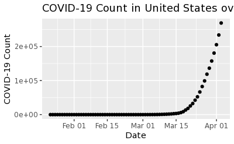

```r
UScovid %>% #Displays a covid count over time graph for the United States
  ggplot(aes(x=Date,y=casecount))+
  geom_point(aes(x=Date,y=casecount))+
  labs(title = "COVID-19 Count in United States over Time", y = "COVID-19 Count")
```

Looking at the scatterplot above, it is apparently that the number of COVID-19 cases is growing exponentially over time. Therefore, looking at the percent of the population in each state with COVID-19 is relevant as researchers are scrambling to develop a mechanism to suppress this exponential rate.

### Looking at the Number of Cases by State

To start, we wanted to look at the number of cases in each state. We used the state abbreviation and added the confirmed cases per county together to find the total count for each state. First is the table showing the state and coronavirus case count, and second is a bar graph illustrating the number of coronavirus cases per state.

```r
sumStates <- #Creates a table of the total number of cases per state
  FullDataCOVID %>%
  group_by(State, rank) %>%
  summarise(count = max(confirmedcases))
sumStates
```

| State | rank | count |
| --- | --- | --- |
| AK | 2 | 157 |
| AL | 1 | 1535 |
| AR | 4 | 725 |
| AZ | 3 | 1769 |
| CA | 5 | 12563 |
| CO | 6 | 4015 |
| CT | 7 | 4697 |
| DC | 9 | 757 |
| DE | 8 | 450 |
| FL | 10 | 10258 |

[output cut: 41 more lines]

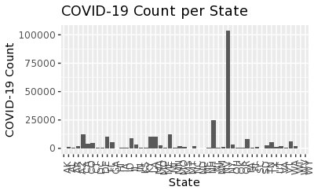

```r
sumStates %>% #Creates a bar graph to show the COVID count per state
  ggplot(aes(x=State,y=count))+
  geom_bar(stat='identity',position='stack')+
  theme(axis.text.x = element_text(angle = 90))+
  labs(title = "COVID-19 Count per State", y = "COVID-19 Count")
```

### Visualizing the COVID-19 count per state on a map

Now that we have looked at the COVID-19 count per state, it is useful to see this visually on a map. First, we needed to find a data table with the coordinates for each state. Then, we created a leaflet map that represents how many people in that state have tested positive for COVID-19.

```r
page <- "https://inkplant.com/code/state-latitudes-longitudes" #This page has a list of coordinates for each State
tableList <- page %>%
  read_html() %>%
  html_nodes(css = "table") %>%
  html_table(fill = TRUE)
coordinates <- tableList[[1]]
statecoordinates <- #Created a table that has State, Latitude, and Longitude of each State (including DC)
  #Ranks are assigned to each state alphabetically so it can match the other tables
  coordinates[2:52,] %>%
  rename(State = X1, Latitude = X2, Longitude = X3) %>%
  mutate(State = as.character(State)) %>%
  mutate(Latitude = as.numeric(Latitude)) %>%
  mutate(Longitude = as.numeric(Longitude)) %>%
  arrange(State) %>%
  mutate(rank = rank(State))
statecoordinates
```

| State | Latitude | Longitude | rank |
| --- | --- | --- | --- |
| Alabama | 32.80667 | -86.79113 | 1 |
| Alaska | 61.37072 | -152.40442 | 2 |
| Arizona | 33.72976 | -111.43122 | 3 |
| Arkansas | 34.96970 | -92.37312 | 4 |
| California | 36.11620 | -119.68156 | 5 |
| Colorado | 39.05981 | -105.31110 | 6 |
| Connecticut | 41.59778 | -72.75537 | 7 |
| Delaware | 39.31852 | -75.50714 | 8 |
| District of Columbia | 38.89744 | -77.02682 | 9 |
| Florida | 27.76628 | -81.68678 | 10 |

[output cut: 41 more lines]

```r
CovidCoordinates <- #The statecoordinates table and the count of COVID cases per state (sumStates) are joined
  sumStates %>%
  select(State,count,rank) %>%
  left_join(statecoordinates %>% select(Latitude, Longitude,rank),
            by = c('rank'='rank'))
CovidCoordinates %>%
  arrange(desc(count))
```

| State | count | rank | Latitude | Longitude |
| --- | --- | --- | --- | --- |
| NY | 103617 | 33 | 42.16573 | -74.94805 |
| NJ | 25087 | 31 | 40.29890 | -74.52101 |
| CA | 12563 | 5 | 36.11620 | -119.68156 |
| MI | 12455 | 23 | 43.32662 | -84.53610 |
| FL | 10258 | 10 | 27.76628 | -81.68678 |
| LA | 10257 | 19 | 31.16955 | -91.86781 |
| MA | 10189 | 22 | 42.23017 | -71.53011 |
| IL | 8851 | 14 | 40.34946 | -88.98614 |
| PA | 8420 | 39 | 40.59075 | -77.20976 |
| WA | 6071 | 48 | 47.40090 | -121.49049 |

[output cut: 41 more lines]

```r
leaflet(CovidCoordinates) %>% #A leaflet is created to represent the COVID count in each State
  addTiles() %>%
  addCircleMarkers(radius = ~ log(count), fillOpacity = 0.5, color="red")
```

```
Assuming "Longitude" and "Latitude" are longitude and latitude, respectively
```

[interactive chart not shown]

```r
#The glyph's size represents how many people in that state have tested positive for COVID (New York is the largest)
```

Looking at this leaflet map, it is evident that New York has the largest number of Coronavirus victims.

### Finding the total state population

To compare the total population per state with the number of coronavirus cases in each state, the total population per state needs to be calculated from the ZipGeography data table.

```r
StatePop <- #This table gets the State and state populations using ZipGeography
  #A rank is assigned to each state so that the rank corresponds with the state alphabetically just like the other tables
  ZipGeography %>%
  mutate(State = as.character(State)) %>%
  group_by(State) %>%
  filter(State != '', Population > 0) %>%
  summarise(statepop = sum(Population)) %>%
  mutate(rank = rank(State))
StatePop %>%
  arrange(desc(statepop))
```

| State | statepop | rank |
| --- | --- | --- |
| California | 33864430 | 5 |
| Texas | 20835778 | 44 |
| New York | 18974619 | 33 |
| Florida | 15979631 | 10 |
| Illinois | 12419037 | 14 |
| Pennsylvania | 12280587 | 39 |
| Ohio | 11353002 | 36 |
| Michigan | 9938204 | 23 |
| New Jersey | 8413990 | 31 |
| Georgia | 8185503 | 11 |

[output cut: 41 more lines]

### Looking at the COVID-19 count over time in states with different population sizes

Now that we have calculated the population for each state, we can look at the rate of COVID-19 in each state. We decided to create scatterplots that illustrate the rate of COVID-19 based on population size. 8 scatterplots were created with the date and confirmed COVID-19 cases.

```r
CovidCasesAndPop <- #Joins the full COVID data table (FullDataCOVID) and the state populations table (StatePop)
  StatePop %>%
  left_join(FullDataCOVID %>% select(rank,Date,confirmedcases),
             by = c("rank" = "rank"))
CovidCasesAndPop
```

| State | statepop | rank | Date | confirmedcases |
| --- | --- | --- | --- | --- |
| Alabama | 4446124 | 1 | 2020-03-13 | 5 |
| Alabama | 4446124 | 1 | 2020-03-14 | 11 |
| Alabama | 4446124 | 1 | 2020-03-15 | 22 |
| Alabama | 4446124 | 1 | 2020-03-16 | 29 |
| Alabama | 4446124 | 1 | 2020-03-17 | 39 |
| Alabama | 4446124 | 1 | 2020-03-18 | 51 |
| Alabama | 4446124 | 1 | 2020-03-19 | 78 |
| Alabama | 4446124 | 1 | 2020-03-20 | 106 |
| Alabama | 4446124 | 1 | 2020-03-21 | 131 |
| Alabama | 4446124 | 1 | 2020-03-22 | 167 |

[output cut: 990 more lines]

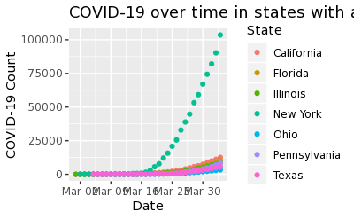

```r
#Scatterplots of COVID count over time are created per state
#States are grouped by state population to make it easier to compare more populated states to each other and vice versa
#The lower the group number, the greater the population
#The dates displayed are from March to now because most states don't have data before March, so filtering it makes it easier to compare and understand
Morethan10M <-
  CovidCasesAndPop %>%
  group_by(rank) %>%
  filter(max(statepop) > 10000000) %>%
  filter(Date >= '2020-03-01')
Morethan10M %>%
  ggplot(aes(x=Date,y=confirmedcases))+
  geom_point(aes(x=Date,y=confirmedcases))+
  aes(colour = State)+
  labs(title = "COVID-19 over time in states with a population over 10M", y = "COVID-19 Count")
```

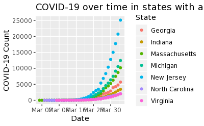

```r
In6Mto10M <-
  CovidCasesAndPop %>%
  group_by(rank) %>%
  filter(max(statepop) <= 10000000) %>%
  filter(max(statepop) > 6000000) %>%
  filter(Date >= '2020-03-01')
In6Mto10M %>%
  ggplot(aes(x=Date,y=confirmedcases))+
  geom_point(aes(x=Date,y=confirmedcases))+
  aes(colour = State)+
  labs(title = "COVID-19 over time in states with a population of 6-10M", y = "COVID-19 Count")
```

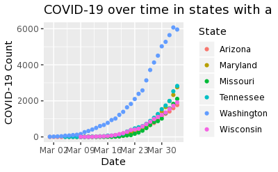

```r
In5Mto6M <-
  CovidCasesAndPop %>%
  group_by(rank) %>%
  filter(max(statepop) <= 6000000) %>%
  filter(max(statepop) > 5000000) %>%
  filter(Date >= '2020-03-01')
In5Mto6M %>%
  ggplot(aes(x=Date,y=confirmedcases))+
  geom_point(aes(x=Date,y=confirmedcases))+
  aes(colour = State)+
  labs(title = "COVID-19 over time in states with a population of 5-6M", y = "COVID-19 Count")
```

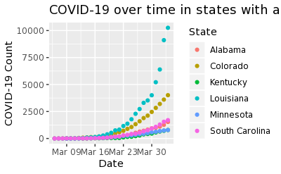

```r
In4Mto5M <-
  CovidCasesAndPop %>%
  group_by(rank) %>%
  filter(max(statepop) <= 5000000) %>%
  filter(max(statepop) > 4000000) %>%
  filter(Date >= '2020-03-01')
In4Mto5M %>%
  ggplot(aes(x=Date,y=confirmedcases))+
  geom_point(aes(x=Date,y=confirmedcases))+
  aes(colour = State)+
  labs(title = "COVID-19 over time in states with a population of 4-5M", y = "COVID-19 Count")
```

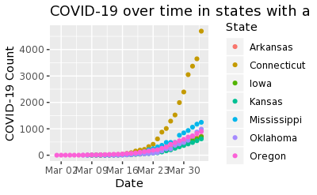

```r
In2.5Mto4M <-
  CovidCasesAndPop %>%
  group_by(rank) %>%
  filter(max(statepop) <= 4000000) %>%
  filter(max(statepop) > 2500000) %>%
  filter(Date >= '2020-03-01')
In2.5Mto4M %>%
  ggplot(aes(x=Date,y=confirmedcases))+
  geom_point(aes(x=Date,y=confirmedcases))+
  aes(colour = State)+
  labs(title = "COVID-19 over time in states with a population of 2.5-4M", y = "COVID-19 Count")
```

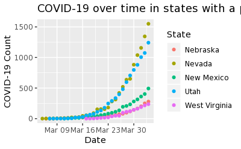

```r
In1.5to2.5M <-
  CovidCasesAndPop %>%
  group_by(rank) %>%
  filter(max(statepop) <= 2500000) %>%
  filter(max(statepop) > 1500000) %>%
  filter(Date >= '2020-03-01')
In1.5to2.5M %>%
  ggplot(aes(x=Date,y=confirmedcases))+
  geom_point(aes(x=Date,y=confirmedcases))+
  aes(colour = State)+
  labs(title = "COVID-19 over time in states with a population of 1.5-2.5M", y = "COVID-19 Count")
```

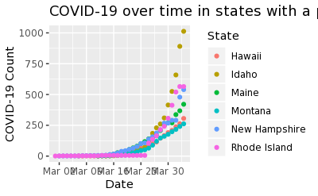

```r
In800Kto1.5M <-
  CovidCasesAndPop %>%
  group_by(rank) %>%
  filter(max(statepop) <= 1500000) %>%
  filter(max(statepop) > 800000) %>%
  filter(Date >= '2020-03-01')
In800Kto1.5M %>%
  ggplot(aes(x=Date,y=confirmedcases))+
  geom_point(aes(x=Date,y=confirmedcases))+
  aes(colour = State)+
  labs(title = "COVID-19 over time in states with a population of 800K-1.5M", y = "COVID-19 Count")
```

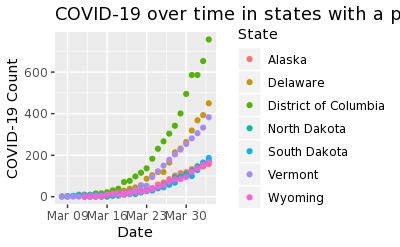

```r
Below800K <-
  CovidCasesAndPop %>%
  group_by(rank) %>%
  filter(max(statepop) <= 800000) %>%
  filter(Date >= '2020-03-01')
Below800K %>%
  ggplot(aes(x=Date,y=confirmedcases))+
  geom_point(aes(x=Date,y=confirmedcases))+
  aes(colour = State)+
  labs(title = "COVID-19 over time in states with a population below 800K", y = "COVID-19 Count")
```

```r
#Each graph has 5, 6, or 7 states represented
```

Looking at these graphs, it is evident that most states, even in comparison other similarly populated states, have a similar COVID-19 count rate. However, there are a few states that have a significantly faster rate in comparison to other similarly populated states. These include New York, New Jersey, and Washington.

# Finding the Percent of the Population with COVID-19

After looking at various relatinoships using total population and coronavirus count, we can find the percent of the population with COVID-19. We can do this by dividing the count (population affected by COVID-19) by the total state population. The table below shows the percent of the population affected.

```r
CovidTotalAndPop <- #The tables of state population (StatePop) and the coronavirus count per state (sumStates) are joined into one big table
  sumStates %>%
  select(State,rank,count) %>%
  left_join(StatePop %>% select(rank,statepop),
            by = c("rank" = "rank")) %>%
  mutate(covid_pop_percent = count/statepop*100) #Creates a percent per state to represent the proportion of the state population has tested positive COVID
CovidTotalAndPop %>%
  arrange(covid_pop_percent)
```

| State | rank | count | statepop | covid_pop_percent |
| --- | --- | --- | --- | --- |
| WV | 49 | 237 | 1807896 | 0.01310916 |
| MN | 24 | 788 | 4914688 | 0.01603357 |
| NE | 28 | 279 | 1703958 | 0.01637364 |
| KY | 18 | 790 | 4025883 | 0.01962302 |
| KS | 17 | 620 | 2685566 | 0.02308638 |
| IA | 16 | 699 | 2892853 | 0.02416300 |
| SD | 42 | 187 | 752418 | 0.02485321 |
| AK | 2 | 157 | 624992 | 0.02512032 |
| HI | 12 | 306 | 1211489 | 0.02525817 |
| NC | 34 | 2093 | 8049254 | 0.02600241 |

[output cut: 41 more lines]

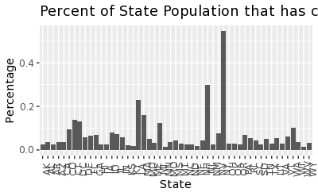

```r
CovidTotalAndPop %>% #Creates a bar graph that shows the COVID count in each state
  ggplot(aes(x=State,y=covid_pop_percent))+
  geom_bar(stat='identity',position='stack')+
  geom_smooth(method = 'lm')+
  theme(axis.text.x = element_text(angle = 90))+
  labs(title = "Percent of State Population that has contracted COVID-19", y = "Percentage")
```

The bar graph illustrates the percent of coronavirus victims as a percent of the total state population for each state. Similar to the bar graph that depicted coronavirus cases and state, the state with the largest percent of the population with COVID-19 is NY with NJ coming in second again. The state with the lowest percent is WV.

### Looking at the COVID-19 Count and the Percent of the State Population who Tested Positive for COVID-19.

Then, we looked at the COVID-19 Count and the percent of the population who tested postive for COVID-19. Looking at the scatterplot below, there seems to be a postive correlation between percent of the state population and COVID-19 count. However, there seems to be an outlier toward the top right of the scatterplot that corresponds to New York.

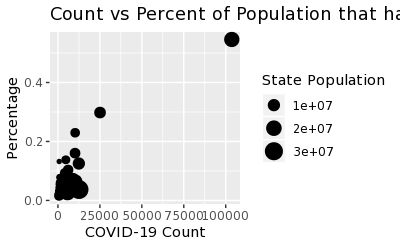

```r
CovidTotalAndPop %>% #Creates a scatterplot that shows the COVID count per state and the percent of the population who tested positive for COVID-19.
  #The size of the glyph also represents the size of the state population
  ggplot(aes(x=count,y=covid_pop_percent,size=statepop))+
  geom_point(aes(x=count,y=covid_pop_percent))+
  labs(title = "Count vs Percent of Population that has COVID-19 per State",
       x = "COVID-19 Count", y = "Percentage", size = "State Population")
```

### Looking at the relationship between COVID-19 Count in each State and the State’s Population

To conclude our analysis and after we determined that the states with the highest COVID-19 count are New York and New Jersey, we decided to look at the relationship between COVID-19 count and the state’s population for the rest of the country. The glyph in the graph below is the state’s abbreviation.

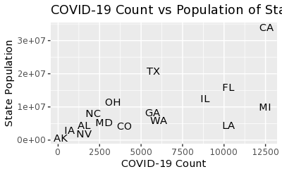

```r
CovidTotalAndPop %>% #Creates a graph comparing the COVID count and the state population.
  #Each state is represented as a glyph as the state's acronym.
  #Removed New York and New Jersey
  filter(State != "NY") %>%
  filter(State !="NJ") %>%
  ggplot(aes(x=count,y=statepop))+
  geom_text(aes(label=State),check_overlap = TRUE)+
  labs(title = "COVID-19 Count vs Population of State (excluding outliers)",
       x = "COVID-19 Count", y = "State Population")
```

Looking at the graph above, there seems to be a positive correlation between State Population and COVID-19 Count without looking at New York and New Jersey. Essentially, as COVID-19 Count increases, the state population increases as well. This means that states with a large population will most likely have a large COVID-19 count.

### Conclusion

To summarize our analysis of these data sets, we first looked at the rate of COVID-19 and established that this is a highly prevalent disease in the United States. This high prevalence of COVID-19 is also seen in the leaflet map and bar graph illustrating the number of COVID-19 cases per state. It was concluded from these graphs that NY and NJ have the highest COVID-19 counts. Then, we looked at the rate of COVID-19 when grouping states by population size. We found that in comparison to states with a similar population, NY, NJ, and WA had the highest COVID-19 rates. Then, we calculated the percent of the state population that had COVID-19. After analyzing this percentage using a bar graph and scatterplot, we decided to create a scatterplot without NY and NJ because the other displays indicated that they were outliers. In the end, we determined that there is a positive correlation between COVID-19 Count and a state’s population with the exception of New York and New Jersey.